# R Lab 10 Key

## T-Tests Set-Up

For this section you will be using nursing data from TidyTuesday. See https://github.com/rfordatascience/tidytuesday/blob/master/data/2021/2021-08-31/readme.md for more detailed information about the dataset.

```r
library(tidyverse)
library(ggplot2)
library(scales)
library(lsr)
set.seed(8765)
nurses <- readr::read_csv('https://raw.githubusercontent.com/rfordatascience/tidytuesday/master/data/2021/2021-10-05/nurses.csv')
nurses$Year <- as.factor(nurses$Year)
nurses$State <- as.factor(nurses$State)

glimpse(nurses)
```

```
## Rows: 1,242
## Columns: 22
## $ State                                             <fct> Alabama, Alaska, Ari…
## $ Year                                              <fct> 2020, 2020, 2020, 20…
## $ `Total Employed RN`                               <dbl> 48850, 6240, 55520, …
## $ `Employed Standard Error (%)`                     <dbl> 2.9, 13.0, 3.7, 4.2,…
## $ `Hourly Wage Avg`                                 <dbl> 28.96, 45.81, 38.64,…
## $ `Hourly Wage Median`                              <dbl> 28.19, 45.23, 37.98,…
## $ `Annual Salary Avg`                               <dbl> 60230, 95270, 80380,…
## $ `Annual Salary Median`                            <dbl> 58630, 94070, 79010,…
## $ `Wage/Salary standard error (%)`                  <dbl> 0.8, 1.4, 0.9, 1.4, …
## $ `Hourly 10th Percentile`                          <dbl> 20.75, 31.50, 27.66,…
## $ `Hourly 25th Percentile`                          <dbl> 23.73, 36.94, 32.58,…
## $ `Hourly 75th Percentile`                          <dbl> 33.15, 53.31, 44.67,…
## $ `Hourly 90th Percentile`                          <dbl> 38.67, 60.70, 50.14,…
## $ `Annual 10th Percentile`                          <dbl> 43150, 65530, 57530,…
## $ `Annual 25th Percentile`                          <dbl> 49360, 76830, 67760,…
## $ `Annual 75th Percentile`                          <dbl> 68960, 110890, 92920…
## $ `Annual 90th Percentile`                          <dbl> 80420, 126260, 10429…
## $ `Location Quotient`                               <dbl> 1.20, 0.98, 0.91, 1.…
## $ `Total Employed (National)_Aggregate`             <dbl> 140019790, 140019790…
## $ `Total Employed (Healthcare, National)_Aggregate` <dbl> 8632190, 8632190, 86…
## $ `Total Employed (Healthcare, State)_Aggregate`    <dbl> 128600, 17730, 17101…
## $ `Yearly Total Employed (State)_Aggregate`         <dbl> 1903210, 296300, 283…
```

### Exercise 1 - Select States

First we will run a t-test comparing two means of `Hourly Wage Avg`. Your first task is to pick two U.S. states that you want to compare. Look at the output of the levels command below and select two states that are of interest to you.

```r
levels(nurses$State)
```

```
##  [1] "Alabama"              "Alaska"               "Arizona"
##  [4] "Arkansas"             "California"           "Colorado"
##  [7] "Connecticut"          "Delaware"             "District of Columbia"
## [10] "Florida"              "Georgia"              "Guam"
## [13] "Hawaii"               "Idaho"                "Illinois"
## [16] "Indiana"              "Iowa"                 "Kansas"
## [19] "Kentucky"             "Louisiana"            "Maine"
## [22] "Maryland"             "Massachusetts"        "Michigan"
## [25] "Minnesota"            "Mississippi"          "Missouri"
## [28] "Montana"              "Nebraska"             "Nevada"
## [31] "New Hampshire"        "New Jersey"           "New Mexico"
## [34] "New York"             "North Carolina"       "North Dakota"
## [37] "Ohio"                 "Oklahoma"             "Oregon"
## [40] "Pennsylvania"         "Puerto Rico"          "Rhode Island"
## [43] "South Carolina"       "South Dakota"         "Tennessee"
## [46] "Texas"                "Utah"                 "Vermont"
## [49] "Virgin Islands"       "Virginia"             "Washington"
## [52] "West Virginia"        "Wisconsin"            "Wyoming"
```

```r
state_nurses <- nurses %>%
  filter(State == "California" |
           State == "Arizona")

state_nurses$State <- droplevels(state_nurses$State)
```

### Exercise 2 - Nurse Hourly Wage t-test

Now you run your t-test. Your goal is to test if there is a significant difference in `Hourly Wage Avg` based on the states (`State`) you selected. *Note:* You will have to write the variable name `Hourly Wage Avg` in the code below within back-ticks “`” because the variable name contains spaces.

```r
t.test(`Hourly Wage Avg` ~ State, data = state_nurses)
```

```
##
##  Welch Two Sample t-test
##
## data:  Hourly Wage Avg by State
## t = -4.0538, df = 35.925, p-value = 0.0002583
## alternative hypothesis: true difference in means between group Arizona and group California is not equal to 0
## 95 percent confidence interval:
##  -14.532362  -4.839811
## sample estimates:
##    mean in group Arizona mean in group California
##                 30.36348                 40.04957
```

### Exercise 3 - Interpret Nurse Hourly Wage t-test

Interpret the above t-test results.

### Exercise 4 - Graphing Nurse Hourly Wage

Below I have created a basic ggplot code chunk to observe the differences. Your task is to improve the graph by: Cleaning up all of the labels, adding a title, make each bar a different color, and add a theme. See https://ggplot2-book.org/polishing.html for a list of included themes. Finally, interpret what you see.

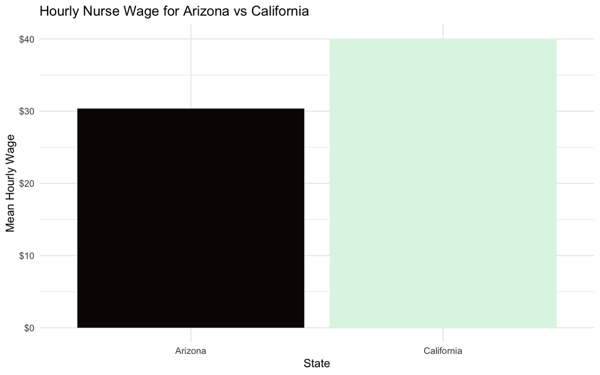

```r
ggplot(state_nurses, aes(State, `Hourly Wage Avg`, fill = State)) +
  stat_summary(fun = mean, geom = "bar") +
  guides(fill = "none") +
  theme_minimal() +
  scale_fill_viridis_d(option = "mako") +
  labs(x = "State", y = "Mean Hourly Wage", title = "Hourly Nurse Wage for Arizona vs California ") +
  scale_y_continuous(labels = dollar_format())
```

### Exercise 5 - Select Years

Next we will run a t-test comparing two means of `Annual Salary Avg`. Your first task is to pick two years that you want to compare. Look at the output of the levels command below and select two years that are of interest to you.

```r
levels(nurses$Year)
```

```
##  [1] "1998" "1999" "2000" "2001" "2002" "2003" "2004" "2005" "2006" "2007"
## [11] "2008" "2009" "2010" "2011" "2012" "2013" "2014" "2015" "2016" "2017"
## [21] "2018" "2019" "2020"
```

In order to run a t-test, our grouping variable (`Year`) can only have two levels. We currently have 23. Below I am creating a new dataset called `year_nurses` that we will use only in this exercise and exercise 10. Fill in and replace “YEAR ONE” and “YEAR TWO” with the two years you selected.

```r
year_nurses <- nurses %>%
  filter(Year == "2011" |
           Year == "2015")

year_nurses$Year <- droplevels(year_nurses$Year)
```

### Exercise 6 - Nurse Annual Salary t-test

Now you run your t-test. This time I am not providing you any starting code. Your goal is to test if there is a significant difference in `Annual Salary Avg` based on the two years you selected. Interpret the t-test results. *Note:* You will have to write the variable name `Annual Salary Avg` in the code below within back-ticks “`” because the variable name contains spaces.

```r
t.test(`Annual Salary Avg` ~ Year, data = year_nurses)
```

```
##
##  Welch Two Sample t-test
##
## data:  Annual Salary Avg by Year
## t = -0.48043, df = 103.45, p-value = 0.6319
## alternative hypothesis: true difference in means between group 2011 and group 2015 is not equal to 0
## 95 percent confidence interval:
##  -5126.916  3127.287
## sample estimates:
## mean in group 2011 mean in group 2015
##           65607.41           66607.22
```

### Exercise 7 - Interpret Nurse Annual Salary t-test

Interpret the above t-test results.

### Exercise 8 - Graphing Nurse Annual Salary

Next, create a ggplot visualization showing the difference in the two means from exercise 6. This time I am not providing any starting code.

Make sure you: Cleaning up all of the labels, adding a title, make each bar a different color, and add a theme. See https://ggplot2-book.org/polishing.html for a list of included themes.

Finally, interpret what you see.

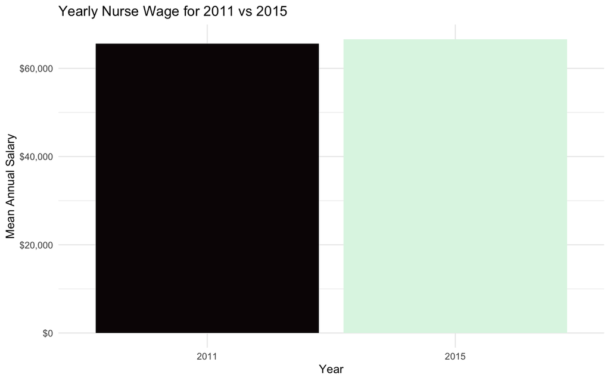

```r
ggplot(year_nurses, aes(Year, `Annual Salary Avg`, fill = Year)) +
  stat_summary(fun = mean, geom = "bar") +
  guides(fill = "none") +
  theme_minimal() +
  scale_fill_viridis_d(option = "mako") +
  labs(x = "Year", y = "Mean Annual Salary", title = "Yearly Nurse Wage for 2011 vs 2015 ") +
  scale_y_continuous(labels = dollar_format())
```

### Exercise 9 - Cohens D Nurse Hourly Wage

Use the `cohensD` function from the `lsr` library to get the effect size. Make sure you set `method = "unequal"`. Interpret the size of the effect.

```r
cohensD(`Hourly Wage Avg` ~ State, data = state_nurses, method = "unequal")
```

```
## [1] 1.195393
```

### Exercise 10 - Cohens D Nurse Annual Salary

Use the `cohensD` function from the `lsr` library to get the effect size. Make sure you set `method = "unequal"`. Interpret the size of the effect.

```r
cohensD(`Annual Salary Avg` ~ Year, data = year_nurses, method = "unequal")
```

```
## [1] 0.09245932
```